# Case study report for Cardiotrophin-1

09 July 2022

**Report for: Cardiotrophin-1 (prot-a-710)**

This case study report includes the results for Cardiotrophin-1, generated automatically using Rmarkdown.

The report is split into 3(+1) parts:

1. Mendelian randomization (MR) results for Cardiotrophin-1 for all breast cancer outcomes (BCAC 2017 and 2020)
2. Overview of potential mediators identified from MR-EvE data; their validation with two-step and multivariable MR (MVMR)
3. Overview of potential mediators identified from literature-mined data; their validation with two-step, bidirectional, and MVMR
4. *Optional* validation of results with female-only exposure data (if available)
- Trait IDs in this report correspond to data available in [OpenGWAS](https://gwas.mrcieu.ac.uk/)
- BCAC 2017 outcomes names/IDs: Full sample (“Breast cancer”) `ieu-a-1126`, ER+ sample (“ER+ Breast cancer”)`ieu-a-1127`, ER- sample (“ER- Breast cancer”) `ieu-a-1128`
- MR analyses in this report were performed using TwoSampleMR and MVMR packages
- The two-sample MR estimates presented in this report were produced with inverse-variance weighted (IVW) or Wald ratio (for single SNP traits)

This report is a part of the publication *“Integrating Mendelian randomization and literature-mined evidence for breast cancer risk factors”* Vabistsevits et al 2022

# 1 Main analysis MR results

Cardiotrophin-1 data details:

- Source: Sun BB 2018
- Sample size: 3301
- nSNPs: 4
- Sample sex: mixed

Cardiotrophin-1 was identified in MR-EvE search as having evidence of effect on breast cancer and validated with IVW MR method in BCAC 2017 and BCAC 2020 breast cancer outcomes:

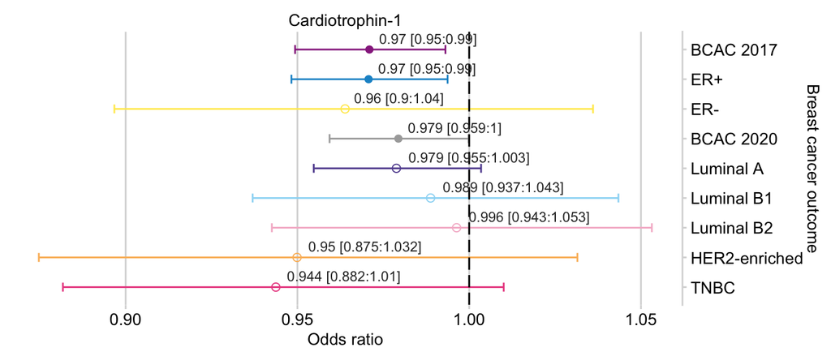

| exposure | outcome | IVW OR | pval | nsnp | Egger intercept < 0.05 | Heterogeneity Qpval < 0.05 |
| --- | --- | --- | --- | --- | --- | --- |
| Cardiotrophin-1 | BCAC 2017 | 0.97 [0.95:0.99] | 0.010 | 3 | FALSE | FALSE |
| Cardiotrophin-1 | ER+ | 0.97 [0.95:0.99] | 0.013 | 3 | FALSE | FALSE |
| Cardiotrophin-1 | ER- | 0.96 [0.9:1.04] | 0.318 | 3 | FALSE | TRUE |
| Cardiotrophin-1 | BCAC 2020 | 0.979 [0.959:1] | 0.048 | 3 | FALSE | FALSE |
| Cardiotrophin-1 | Luminal A | 0.979 [0.955:1.003] | 0.091 | 3 | FALSE | FALSE |
| Cardiotrophin-1 | Luminal B1 | 0.989 [0.937:1.043] | 0.681 | 3 | FALSE | FALSE |
| Cardiotrophin-1 | Luminal B2 | 0.996 [0.943:1.053] | 0.897 | 3 | FALSE | FALSE |
| Cardiotrophin-1 | HER2-enriched | 0.95 [0.875:1.032] | 0.222 | 3 | FALSE | FALSE |
| Cardiotrophin-1 | TNBC | 0.944 [0.882:1.01] | 0.095 | 3 | FALSE | FALSE |

The full MR results and sensitivity analysis are available in Supplementary Data 2 and 3.

# 2 MR-EvE-mined mediators

By querying MR-EvE data for Cardiotrophin-1 we identified 31 potential mediators. This analysis was done only for BCAC 2017 outcomes (full / ER+ / ER-), and only those that were affected in the main MR analysis: full , ER+ , sample(s)

Below is a table of two-step MR results for each mediator, including *exposure -> mediator* and *mediator -> outcome*. The total effect of *exposure -> outcome* is available in the table above.

## 2.1 Two-step MR

**Full sample**: 23 potential mediators from MR-EvE

| exposure | outcome | mediator.id | mediator | exposure -> mediator (step1) beta_CI | nSNPs (step1) | mediator -> outcome (step2) OR_CI | nSNPs (step2) |
| --- | --- | --- | --- | --- | --- | --- | --- |
| Cardiotrophin-1 | BCAC 2017 | ukb-d-30770_irnt | IGF-1 | 0.02 [0.01:0.03] | 3 | 1.07 [1.01:1.13] | 318 |
| Cardiotrophin-1 | BCAC 2017 | ukb-d-1418_3 | Milk type used: Skimmed | 0.01 [0:0.01] | 3 | 0.01 [0:0.35] | 3 |
| Cardiotrophin-1 | BCAC 2017 | ukb-b-4424 | Sleep duration | -0.01 [-0.01:0] | 3 | 1.33 [1.01:1.74] | 66 |
| Cardiotrophin-1 | BCAC 2017 | ukb-b-3881 | Fresh fruit intake | 0.01 [0.01:0.01] | 3 | 0.64 [0.46:0.9] | 53 |
| Cardiotrophin-1 | BCAC 2017 | ukb-b-16576 | Dried fruit intake | 0.02 [0.02:0.03] | 3 | 0.54 [0.4:0.73] | 40 |
| Cardiotrophin-1 | BCAC 2017 | ukb-a-487 | Types of physical activity in last 4 weeks: Heavy DIY (eg: weeding lawn mowing carpentry digging) | 0.01 [0:0.01] | 3 | 0.33 [0.11:0.99] | 3 |
| Cardiotrophin-1 | BCAC 2017 | ukb-a-34 | Comparative body size at age 10 | 0.01 [0:0.01] | 3 | 0.64 [0.56:0.73] | 144 |
| Cardiotrophin-1 | BCAC 2017 | ukb-a-11 | Morning/evening person (chronotype) | -0.02 [-0.02:-0.01] | 3 | 1.31 [1.13:1.51] | 77 |
| Cardiotrophin-1 | BCAC 2017 | prot-a-366 | Calpastatin | -0.1 [-0.18:-0.02] | 3 | 1.06 [1.02:1.09] | 4 |
| Cardiotrophin-1 | BCAC 2017 | prot-a-305 | Complement C1q tumor necrosis factor-related protein 5 | -0.12 [-0.19:-0.04] | 3 | 0.92 [0.88:0.97] | 4 |
| Cardiotrophin-1 | BCAC 2017 | prot-a-2930 | Tubulin-specific chaperone A | -1.37 [-2.4:-0.35] | 3 | 1.02 [1:1.04] | 2 |
| Cardiotrophin-1 | BCAC 2017 | prot-a-2891 | Extracellular sulfatase Sulf-2 | -0.13 [-0.2:-0.06] | 3 | 0.96 [0.92:1] | 3 |
| Cardiotrophin-1 | BCAC 2017 | prot-a-1506 | Interleukin-21 | 0.09 [0.01:0.16] | 3 | 1.05 [1.01:1.09] | 3 |
| Cardiotrophin-1 | BCAC 2017 | prot-a-1411 | Alpha-L-iduronidase | -0.09 [-0.17:-0.02] | 3 | 1.02 [1:1.04] | 2 |
| Cardiotrophin-1 | BCAC 2017 | met-c-956 | Triglycerides in very small VLDL | 0.13 [0.09:0.17] | 3 | 0.95 [0.91:1] | 19 |
| Cardiotrophin-1 | BCAC 2017 | met-c-932 | Triglycerides in small VLDL | 0.11 [0.03:0.19] | 3 | 0.91 [0.88:0.94] | 14 |
| Cardiotrophin-1 | BCAC 2017 | met-c-928 | Free cholesterol in small VLDL | 0.17 [0.14:0.2] | 3 | 0.93 [0.88:0.97] | 14 |
| Cardiotrophin-1 | BCAC 2017 | met-c-922 | Concentration of small HDL particles | 0.06 [0:0.11] | 3 | 0.92 [0.87:0.98] | 5 |
| Cardiotrophin-1 | BCAC 2017 | met-c-914 | Phospholipids in medium VLDL | 0.1 [0:0.2] | 3 | 0.91 [0.87:0.96] | 15 |
| Cardiotrophin-1 | BCAC 2017 | met-c-909 | Total cholesterol in medium VLDL | 0.11 [0.02:0.2] | 3 | 0.93 [0.88:0.98] | 15 |
| Cardiotrophin-1 | BCAC 2017 | met-c-900 | Free cholesterol in medium HDL | -0.05 [-0.1:0] | 3 | 1.09 [1.02:1.16] | 5 |
| Cardiotrophin-1 | BCAC 2017 | met-c-875 | Cholesterol esters in large HDL | -0.12 [-0.17:-0.08] | 3 | 1.06 [1.02:1.11] | 13 |
| Cardiotrophin-1 | BCAC 2017 | met-c-874 | Total cholesterol in large HDL | -0.12 [-0.15:-0.09] | 3 | 1.06 [1.02:1.11] | 14 |

**ER+ sample**: 26 potential mediators from MR-EvE

| exposure | outcome | mediator.id | mediator | exposure -> mediator (step1) beta_CI | nSNPs (step1) | mediator -> outcome (step2) OR_CI | nSNPs (step2) |
| --- | --- | --- | --- | --- | --- | --- | --- |
| Cardiotrophin-1 | ER+ | ukb-d-30770_irnt | IGF-1 | 0.02 [0.01:0.03] | 3 | 1.06 [1:1.13] | 318 |
| Cardiotrophin-1 | ER+ | ukb-d-1418_3 | Milk type used: Skimmed | 0.01 [0:0.01] | 3 | 0.01 [0:0.15] | 3 |
| Cardiotrophin-1 | ER+ | ukb-b-4424 | Sleep duration | -0.01 [-0.01:0] | 3 | 1.49 [1.12:2] | 66 |
| Cardiotrophin-1 | ER+ | ukb-b-3881 | Fresh fruit intake | 0.01 [0.01:0.01] | 3 | 0.65 [0.44:0.95] | 53 |
| Cardiotrophin-1 | ER+ | ukb-b-14926 | Types of transport used (excluding work): Walk | 0.01 [0:0.01] | 3 | 0.21 [0.07:0.66] | 7 |
| Cardiotrophin-1 | ER+ | ukb-a-34 | Comparative body size at age 10 | 0.01 [0:0.01] | 3 | 0.67 [0.58:0.77] | 144 |
| Cardiotrophin-1 | ER+ | ukb-a-11 | Morning/evening person (chronotype) | -0.02 [-0.02:-0.01] | 3 | 1.4 [1.2:1.64] | 77 |
| Cardiotrophin-1 | ER+ | prot-a-670 | C-reactive protein | -0.19 [-0.36:-0.01] | 3 | 1.07 [1.02:1.13] | 3 |
| Cardiotrophin-1 | ER+ | prot-a-586 | Dual specificity protein kinase CLK2 | 0.18 [0.11:0.26] | 3 | 0.96 [0.92:0.99] | 3 |
| Cardiotrophin-1 | ER+ | prot-a-366 | Calpastatin | -0.1 [-0.18:-0.02] | 3 | 1.07 [1.02:1.13] | 4 |
| Cardiotrophin-1 | ER+ | prot-a-3093 | Protein-tyrosine sulfotransferase 2 | -0.1 [-0.17:-0.03] | 3 | 1.06 [1:1.12] | 4 |
| Cardiotrophin-1 | ER+ | prot-a-305 | Complement C1q tumor necrosis factor-related protein 5 | -0.12 [-0.19:-0.04] | 3 | 0.92 [0.87:0.97] | 4 |
| Cardiotrophin-1 | ER+ | prot-a-2073 | Pro-FMRFamide-related neuropeptide FF | -0.08 [-0.15:-0.01] | 3 | 0.97 [0.95:0.99] | 3 |
| Cardiotrophin-1 | ER+ | prot-a-1506 | Interleukin-21 | 0.09 [0.01:0.16] | 3 | 1.05 [1:1.09] | 3 |
| Cardiotrophin-1 | ER+ | met-c-956 | Triglycerides in very small VLDL | 0.13 [0.09:0.17] | 3 | 0.94 [0.89:0.99] | 19 |
| Cardiotrophin-1 | ER+ | met-c-932 | Triglycerides in small VLDL | 0.11 [0.03:0.19] | 3 | 0.9 [0.86:0.93] | 14 |
| Cardiotrophin-1 | ER+ | met-c-928 | Free cholesterol in small VLDL | 0.17 [0.14:0.2] | 3 | 0.91 [0.87:0.96] | 14 |
| Cardiotrophin-1 | ER+ | met-c-927 | Total cholesterol in small VLDL | 0.18 [0.14:0.22] | 3 | 0.93 [0.88:0.98] | 16 |
| Cardiotrophin-1 | ER+ | met-c-922 | Concentration of small HDL particles | 0.06 [0:0.11] | 3 | 0.9 [0.84:0.96] | 5 |
| Cardiotrophin-1 | ER+ | met-c-914 | Phospholipids in medium VLDL | 0.1 [0:0.2] | 3 | 0.9 [0.86:0.94] | 15 |
| Cardiotrophin-1 | ER+ | met-c-909 | Total cholesterol in medium VLDL | 0.11 [0.02:0.2] | 3 | 0.92 [0.87:0.96] | 15 |
| Cardiotrophin-1 | ER+ | met-c-900 | Free cholesterol in medium HDL | -0.05 [-0.1:0] | 3 | 1.12 [1.04:1.21] | 5 |
| Cardiotrophin-1 | ER+ | met-c-898 | Total cholesterol in medium HDL | -0.11 [-0.14:-0.07] | 3 | 1.14 [1.05:1.23] | 6 |
| Cardiotrophin-1 | ER+ | met-c-875 | Cholesterol esters in large HDL | -0.12 [-0.17:-0.08] | 3 | 1.07 [1.02:1.13] | 13 |
| Cardiotrophin-1 | ER+ | met-c-874 | Total cholesterol in large HDL | -0.12 [-0.15:-0.09] | 3 | 1.07 [1.02:1.13] | 14 |
| Cardiotrophin-1 | ER+ | met-c-864 | Total cholesterol in HDL | -0.05 [-0.08:-0.02] | 3 | 1.06 [1.01:1.11] | 12 |

## 2.2 MVMR

Next, we performed MVMR with potential mediators. In the table below, we include the total effect from univariable MR and the direct effect from MVMR accounted for each mediator. The mediator traits that disrupt the total effect are highlighted.

12 traits attenuate the effect of Cardiotrophin-1 on **breast cancer (full sample)** (highlighted):

| exposure | outcome | mediator | Total effect exposure -> outcome | Exp SNPs (total) | Direct effect exposure -> outcome | Exp SNPs (direct) | Med SNPs (direct) | is_disrupted |
| --- | --- | --- | --- | --- | --- | --- | --- | --- |
| Cardiotrophin-1 | Breast cancer | IGF-1 | 0.97 [0.95:0.99] | 3 | 0.97 [0.94:1] | 3 | 311 | FALSE |
| Cardiotrophin-1 | Breast cancer | Milk type used: Skimmed | 0.97 [0.95:0.99] | 3 | 1 [0.94:1.06] | 3 | 3 | TRUE |
| Cardiotrophin-1 | Breast cancer | Sleep duration | 0.97 [0.95:0.99] | 3 | 0.98 [0.94:1.01] | 3 | 65 | TRUE |
| Cardiotrophin-1 | Breast cancer | Fresh fruit intake | 0.97 [0.95:0.99] | 3 | 0.98 [0.95:1.01] | 3 | 54 | TRUE |
| Cardiotrophin-1 | Breast cancer | Dried fruit intake | 0.97 [0.95:0.99] | 3 | 0.98 [0.95:1.01] | 3 | 40 | TRUE |
| Cardiotrophin-1 | Breast cancer | Types of physical activity in last 4 weeks: Heavy DIY (eg: weeding lawn mowing carpentry digging) | 0.97 [0.95:0.99] | 3 | 0.98 [0.95:1] | 3 | 3 | FALSE |
| Cardiotrophin-1 | Breast cancer | Comparative body size at age 10 | 0.97 [0.95:0.99] | 3 | 0.97 [0.94:1] | 3 | 142 | FALSE |
| Cardiotrophin-1 | Breast cancer | Morning/evening person (chronotype) | 0.97 [0.95:0.99] | 3 | 0.98 [0.95:1.01] | 3 | 76 | TRUE |
| Cardiotrophin-1 | Breast cancer | Calpastatin | 0.97 [0.95:0.99] | 3 | 0.98 [0.96:0.99] | 3 | 4 | FALSE |
| Cardiotrophin-1 | Breast cancer | Complement C1q tumor necrosis factor-related protein 5 | 0.97 [0.95:0.99] | 3 | 0.96 [0.94:0.99] | 3 | 4 | FALSE |
| Cardiotrophin-1 | Breast cancer | Tubulin-specific chaperone A | 0.97 [0.95:0.99] | 3 | 0.98 [0.93:1.03] | 3 | 2 | TRUE |
| Cardiotrophin-1 | Breast cancer | Extracellular sulfatase Sulf-2 | 0.97 [0.95:0.99] | 3 | 0.97 [0.94:0.99] | 3 | 3 | FALSE |
| Cardiotrophin-1 | Breast cancer | Interleukin-21 | 0.97 [0.95:0.99] | 3 | 0.97 [0.95:0.99] | 3 | 3 | FALSE |
| Cardiotrophin-1 | Breast cancer | Alpha-L-iduronidase | 0.97 [0.95:0.99] | 3 | 0.97 [0.96:0.99] | 3 | 2 | FALSE |
| Cardiotrophin-1 | Breast cancer | Triglycerides in very small VLDL | 0.97 [0.95:0.99] | 3 | 0.97 [0.95:1] | 4 | 20 | FALSE |
| Cardiotrophin-1 | Breast cancer | Triglycerides in small VLDL | 0.97 [0.95:0.99] | 3 | 0.98 [0.96:1] | 3 | 15 | TRUE |
| Cardiotrophin-1 | Breast cancer | Free cholesterol in small VLDL | 0.97 [0.95:0.99] | 3 | 0.98 [0.96:1.01] | 3 | 14 | TRUE |
| Cardiotrophin-1 | Breast cancer | Concentration of small HDL particles | 0.97 [0.95:0.99] | 3 | 0.97 [0.95:0.99] | 3 | 5 | FALSE |
| Cardiotrophin-1 | Breast cancer | Phospholipids in medium VLDL | 0.97 [0.95:0.99] | 3 | 0.98 [0.95:1] | 3 | 16 | TRUE |
| Cardiotrophin-1 | Breast cancer | Total cholesterol in medium VLDL | 0.97 [0.95:0.99] | 3 | 0.98 [0.95:1] | 3 | 16 | TRUE |
| Cardiotrophin-1 | Breast cancer | Free cholesterol in medium HDL | 0.97 [0.95:0.99] | 3 | 0.98 [0.96:0.99] | 3 | 5 | FALSE |
| Cardiotrophin-1 | Breast cancer | Cholesterol esters in large HDL | 0.97 [0.95:0.99] | 3 | 0.98 [0.96:1] | 3 | 13 | TRUE |
| Cardiotrophin-1 | Breast cancer | Total cholesterol in large HDL | 0.97 [0.95:0.99] | 3 | 0.98 [0.96:1] | 3 | 14 | TRUE |

19 traits attenuate the effect of Cardiotrophin-1 on **ER+ breast cancer** (highlighted):

| exposure | outcome | mediator | Total effect exposure -> outcome | Exp SNPs (total) | Direct effect exposure -> outcome | Exp SNPs (direct) | Med SNPs (direct) | is_disrupted |
| --- | --- | --- | --- | --- | --- | --- | --- | --- |
| Cardiotrophin-1 | ER+ Breast cancer | IGF-1 | 0.97 [0.95:0.99] | 3 | 0.97 [0.94:1] | 3 | 311 | TRUE |
| Cardiotrophin-1 | ER+ Breast cancer | Milk type used: Skimmed | 0.97 [0.95:0.99] | 3 | 1 [0.95:1.05] | 3 | 3 | TRUE |
| Cardiotrophin-1 | ER+ Breast cancer | Sleep duration | 0.97 [0.95:0.99] | 3 | 0.97 [0.94:1.01] | 3 | 65 | TRUE |
| Cardiotrophin-1 | ER+ Breast cancer | Fresh fruit intake | 0.97 [0.95:0.99] | 3 | 0.97 [0.94:1.01] | 3 | 54 | TRUE |
| Cardiotrophin-1 | ER+ Breast cancer | Types of transport used (excluding work): Walk | 0.97 [0.95:0.99] | 3 | 0.98 [0.95:1.01] | 3 | 7 | TRUE |
| Cardiotrophin-1 | ER+ Breast cancer | Comparative body size at age 10 | 0.97 [0.95:0.99] | 3 | 0.96 [0.93:0.99] | 3 | 142 | FALSE |
| Cardiotrophin-1 | ER+ Breast cancer | Morning/evening person (chronotype) | 0.97 [0.95:0.99] | 3 | 0.98 [0.95:1.01] | 3 | 76 | TRUE |
| Cardiotrophin-1 | ER+ Breast cancer | C-reactive protein | 0.97 [0.95:0.99] | 3 | 0.98 [0.96:1] | 4 | 4 | FALSE |
| Cardiotrophin-1 | ER+ Breast cancer | Dual specificity protein kinase CLK2 | 0.97 [0.95:0.99] | 3 | 0.98 [0.96:1] | 3 | 3 | TRUE |
| Cardiotrophin-1 | ER+ Breast cancer | Calpastatin | 0.97 [0.95:0.99] | 3 | 0.98 [0.95:1.01] | 3 | 4 | TRUE |
| Cardiotrophin-1 | ER+ Breast cancer | Protein-tyrosine sulfotransferase 2 | 0.97 [0.95:0.99] | 3 | 0.98 [0.94:1.01] | 3 | 4 | TRUE |
| Cardiotrophin-1 | ER+ Breast cancer | Complement C1q tumor necrosis factor-related protein 5 | 0.97 [0.95:0.99] | 3 | 0.96 [0.93:0.99] | 3 | 4 | FALSE |
| Cardiotrophin-1 | ER+ Breast cancer | Pro-FMRFamide-related neuropeptide FF | 0.97 [0.95:0.99] | 3 | 0.97 [0.95:0.99] | 3 | 3 | FALSE |
| Cardiotrophin-1 | ER+ Breast cancer | Interleukin-21 | 0.97 [0.95:0.99] | 3 | 0.97 [0.94:0.99] | 3 | 3 | FALSE |
| Cardiotrophin-1 | ER+ Breast cancer | Triglycerides in very small VLDL | 0.97 [0.95:0.99] | 3 | 0.97 [0.95:1] | 4 | 20 | TRUE |
| Cardiotrophin-1 | ER+ Breast cancer | Triglycerides in small VLDL | 0.97 [0.95:0.99] | 3 | 0.98 [0.96:1] | 3 | 15 | TRUE |
| Cardiotrophin-1 | ER+ Breast cancer | Free cholesterol in small VLDL | 0.97 [0.95:0.99] | 3 | 0.99 [0.96:1.01] | 3 | 14 | TRUE |
| Cardiotrophin-1 | ER+ Breast cancer | Total cholesterol in small VLDL | 0.97 [0.95:0.99] | 3 | 0.98 [0.95:1.01] | 3 | 15 | TRUE |
| Cardiotrophin-1 | ER+ Breast cancer | Concentration of small HDL particles | 0.97 [0.95:0.99] | 3 | 0.97 [0.95:1] | 3 | 5 | TRUE |
| Cardiotrophin-1 | ER+ Breast cancer | Phospholipids in medium VLDL | 0.97 [0.95:0.99] | 3 | 0.98 [0.96:1.01] | 3 | 16 | TRUE |
| Cardiotrophin-1 | ER+ Breast cancer | Total cholesterol in medium VLDL | 0.97 [0.95:0.99] | 3 | 0.98 [0.95:1.01] | 3 | 16 | TRUE |
| Cardiotrophin-1 | ER+ Breast cancer | Free cholesterol in medium HDL | 0.97 [0.95:0.99] | 3 | 0.98 [0.96:1] | 3 | 5 | FALSE |
| Cardiotrophin-1 | ER+ Breast cancer | Total cholesterol in medium HDL | 0.97 [0.95:0.99] | 3 | 0.98 [0.96:1.01] | 3 | 6 | TRUE |
| Cardiotrophin-1 | ER+ Breast cancer | Cholesterol esters in large HDL | 0.97 [0.95:0.99] | 3 | 0.98 [0.95:1.01] | 3 | 13 | TRUE |
| Cardiotrophin-1 | ER+ Breast cancer | Total cholesterol in large HDL | 0.97 [0.95:0.99] | 3 | 0.98 [0.95:1.01] | 3 | 14 | TRUE |
| Cardiotrophin-1 | ER+ Breast cancer | Total cholesterol in HDL | 0.97 [0.95:0.99] | 3 | 0.97 [0.95:1] | 3 | 12 | FALSE |

# 3 Literature-mined mediators

We searched literature-mined relationships in EpiGraphDB for Cardiotrophin-1 and breast cancer and used literature-overlap method to identify potential intermediates between the two. The identified intermediates are tested as potential mediaotrs in this section.

## 3.1 Summary

Cardiotrophin-1 literature space contains:

- 136 unique triples of terms
- 123 unique pairs of terms

## 3.2 Literature overlap Sankey plot

This is a Sankey plot of literature overlap between Cardiotrophin-1 and breast cancer. See the subset versions and explore filters in a separate app: https://mvab.shinyapps.io/literature_overlap_sankey/

[interactive chart not shown]

## 3.3 Matching literature terms to GWAS traits

Cardiotrophin-1 and breast cancer literature space overlap identified:

| Literature term | Matching GWAS in OpenGWAS | GWAS ID | nSNPs p < 5x10e8 |
| --- | --- | --- | --- |
| AKT1 | prot-a-70 | RAC-alpha/beta/gamma serine/threonine-protein kinase | 1 |
| AKT1 | prot-a-71 | RAC-alpha/beta/gamma serine/threonine-protein kinase | 1 |
| leukemia inhibitory factor receptor | ebi-a-GCST90000482 | Leukemia inhibitory factor receptor levels | 0 |
| leukemia inhibitory factor receptor | prot-a-1736 | Leukemia inhibitory factor | 1 |
| leukemia inhibitory factor receptor | prot-c-4919_56_2 | LIF sR | 0 |
| leukemia inhibitory factor receptor | prot-a-1737 | Leukemia inhibitory factor receptor | 1 |
| CA2 | prot-c-4970_55_1 | carbonic anhydrase II | 0 |
| CA2 | prot-a-329 | Carbonic anhydrase 2 | 0 |
| Vasoactive Intestinal Peptide | prot-c-3522_57_1 | Vasoactive Intestinal Peptide | 0 |
| HSP90B2P | prot-a-1384 | Heat shock protein HSP 90-alpha/beta | 0 |
| HSP90B2P | prot-c-2625_53_4 | HSP 90a/b | 0 |
| HSP90B2P | prot-a-1385 | Heat shock protein HSP 90-beta | 0 |
| IL6 | prot-c-4673_13_2 | IL-6 | 0 |
| IL6 | prot-b-2 | interleukin 6 | 0 |
| IL6 | ebi-a-GCST004446 | Interleukin-6 levels | 0 |
| IL6 | ebi-a-GCST90000478 | Interleukin-6 levels | 0 |
| IL6 | prot-a-1538 | Interleukin-6 | 0 |
| MAPK1 | prot-c-3115_64_2 | MK01 | 0 |
| MAPK1 | prot-a-1845 | Mitogen-activated protein kinase 1 | 1 |
| oncostatin M | prot-a-2155 | Oncostatin-M | 2 |
| oncostatin M | ebi-a-GCST90000491 | Oncostatin-M levels | 0 |
| oncostatin M | prot-c-2693_20_3 | OSM | 0 |
| STAT3 | prot-a-2869 | Signal transducer and activator of transcription 3 | 2 |
| VEGFA | ebi-a-GCST90000506 | Vascular endothelial growth factor A levels | 0 |
| VEGFA | prot-b-22 | vascular endothelial growth factor A | 0 |
| VEGFA | prot-a-3198 | Vascular endothelial growth factor A | 1 |
| VEGFA | prot-c-2597_8_3 | VEGF | 0 |
| ERBB2 | prot-a-973 | Receptor tyrosine-protein kinase erbB-2 | 0 |
| ERBB2 | prot-c-2616_23_18 | ERBB2 | 0 |
| Estrogen Receptors | prot-c-2945_25_1 | ER | 0 |
| Estrogen Receptors | prot-a-991 | Estrogen receptor | 0 |
| pituitary adenylate cyclase activating polypeptide | prot-a-42 | Pituitary adenylate cyclase-activating polypeptide | 1 |

## 3.4 Two-step MR (step 2)

We performed two-step MR for 9 traits with >=1 instruments (highlighted in table above):

- RAC-alpha/beta/gamma serine/threonine-protein kinase
- Leukemia inhibitory factor
- Leukemia inhibitory factor receptor
- Mitogen-activated protein kinase 1
- Oncostatin-M
- Signal transducer and activator of transcription 3
- Vascular endothelial growth factor A
- Pituitary adenylate cyclase-activating polypeptide

Out of these traits, 2 had evidence of effect on breast cancer (so could be considered further as potential mediators):

- Leukemia inhibitory factor receptor
- Leukemia inhibitory factor

**Mediator -> outcome (step2) MR results** for the traits with evidence of effect:

| exposure | id.exposure | outcome | OR_CI | nsnp |
| --- | --- | --- | --- | --- |
| Leukemia inhibitory factor receptor | prot-a-1737 | Breast cancer | 0.87 [0.82:0.91] | 1 |
| Leukemia inhibitory factor | prot-a-1736 | ER+ Breast cancer | 1.1 [1.02:1.18] | 1 |
| Leukemia inhibitory factor receptor | prot-a-1737 | ER+ Breast cancer | 0.87 [0.82:0.92] | 1 |

## 3.5 Bidirectional MR (exp/med) (step1)

We next performed bidirectional MR to to establish the direction of the effect between the intermediate and the risk factor and identify the traits that are affected by the risk factor (i.e. likely mediator relationship) [**Exposure -> mediator (step1 of two-step MR)**] and the other way around (i.e. potential confounder relationship).

The table below highlights the relationships with evidence of effect.

Potential mediators: **Leukemia inhibitory factor** (traits affect by Cardiotrophin-1)

| exposure | id.exposure | outcome | id.outcome | beta_CI | effect_direction | nsnp | effect |
| --- | --- | --- | --- | --- | --- | --- | --- |
| Cardiotrophin-1 | prot-a-710 | Leukemia inhibitory factor receptor | prot-a-1737 | -0.04 [-0.11:0.03] | overlaps null | 3 | term trait as mediator |
| Leukemia inhibitory factor receptor | prot-a-1737 | Cardiotrophin-1 | prot-a-710 | -0.05 [-0.26:0.16] | overlaps null | 1 | term trait as confounder |
| Cardiotrophin-1 | prot-a-710 | Leukemia inhibitory factor | prot-a-1736 | -0.11 [-0.18:-0.04] | negative | 3 | term trait as mediator |
| Leukemia inhibitory factor | prot-a-1736 | Cardiotrophin-1 | prot-a-710 | 0.03 [-0.21:0.27] | overlaps null | 1 | term trait as confounder |

## 3.6 MVMR

For the identified potential mediators we perform MVMR with the known affected outcomes. The table below shows the total effect of exposure (Cardiotrophin-1) and each mediator, and their direct effects from MVMR analysis together.

The highlighted rows indicate when the direct effect overlaps the null.

| # | exposure/mediator | outcome | total effect (MR) | total effect direction | SNPs in total | direct effect (MVMR) | direct effect direction | SNPs in direct |
| --- | --- | --- | --- | --- | --- | --- | --- | --- |
| 1 |  |  |  |  |  |  |  |  |
|  | Cardiotrophin-1 | ER+ Breast cancer | 0.97 [0.95:0.99] | negative | 3 | 0.98 [0.95:1.01] | overlaps null | 3 |
|  | Leukemia inhibitory factor | ER+ Breast cancer | 1.1 [1.02:1.18] | positive | 1 | 1.09 [1.01:1.18] | positive | 1 |